# Kristen_Assignment1

Kristen

2024-09-15

## Part 1: Explore data

1. Make a histogram of the scores to visualize the overall distribution of scores. Change the number of bins from the default to 10, 15, 20, and 25. Pick on the one that you think looks the best. Explain what the difference is when you change the number of bins and explain why you picked the one you did.

```r
## Install the tidytuesdayR package if you don't have it
if (!require("tidytuesdayR", quietly = TRUE)) {
  install.packages("tidytuesdayR")
}

## Install the here package if you don't have it
if (!require("here", quietly = TRUE)) {
  install.packages("here")
}
```

```
## here() starts at D:/master/course/term5/R computing/assignment1/assignment1
```

```r
## For the GitHub version of tidytuesdayR (in case the CRAN version is not available)
## you'll need the "remotes" package to install it.
## See for example https://github.com/dslc-io/tidytuesdayR/issues/94 which led
## to tidytuesdayR not been available from CRAN at the end of August 2024

## Install the remotes package if you don't have it
if (!require("remotes", quietly = TRUE)) {
  install.packages("remotes")
}
## Install the tidytuesdayR package (from GitHub) if you don't have it
if (!require("tidytuesdayR", quietly = TRUE)) {
  remotes::install_github("dslc-io/tidytuesdayR")
}


library("here")
library("tidyverse")
# tests if a directory named "data" exists locally
if (!dir.exists(here("data"))) {
  dir.create(here("data"))
}

# saves data only once (not each time you knit a R Markdown)
if (!file.exists(here("data", "chocolate.RDS"))) {
  url_csv <- "https://raw.githubusercontent.com/rfordatascience/tidytuesday/master/data/2022/2022-01-18/chocolate.csv"
  chocolate <- readr::read_csv(url_csv)

  # save the file to RDS objects
  saveRDS(chocolate, file = here("data", "chocolate.RDS"))
}

chocolate <- readRDS(here("data", "chocolate.RDS"))
as_tibble(chocolate)
```

```
## # A tibble: 2,530 × 10
##      ref company_manufacturer company_location review_date
##    <dbl> <chr>                <chr>                  <dbl>
##  1  2454 5150                 U.S.A.                  2019
##  2  2458 5150                 U.S.A.                  2019
##  3  2454 5150                 U.S.A.                  2019
##  4  2542 5150                 U.S.A.                  2021
##  5  2546 5150                 U.S.A.                  2021
##  6  2546 5150                 U.S.A.                  2021
##  7  2542 5150                 U.S.A.                  2021
##  8   797 A. Morin             France                  2012
##  9   797 A. Morin             France                  2012
## 10  1011 A. Morin             France                  2013
## # ℹ 2,520 more rows
## # ℹ 6 more variables: country_of_bean_origin <chr>,
## #   specific_bean_origin_or_bar_name <chr>, cocoa_percent <chr>,
## #   ingredients <chr>, most_memorable_characteristics <chr>, rating <dbl>
```

```r
glimpse(chocolate)
```

```
## Rows: 2,530
## Columns: 10
## $ ref                              <dbl> 2454, 2458, 2454, 2542, 2546, 2546, 2…
## $ company_manufacturer             <chr> "5150", "5150", "5150", "5150", "5150…
## $ company_location                 <chr> "U.S.A.", "U.S.A.", "U.S.A.", "U.S.A.…
## $ review_date                      <dbl> 2019, 2019, 2019, 2021, 2021, 2021, 2…
## $ country_of_bean_origin           <chr> "Tanzania", "Dominican Republic", "Ma…
## $ specific_bean_origin_or_bar_name <chr> "Kokoa Kamili, batch 1", "Zorzal, bat…
## $ cocoa_percent                    <chr> "76%", "76%", "76%", "68%", "72%", "8…
## $ ingredients                      <chr> "3- B,S,C", "3- B,S,C", "3- B,S,C", "…
## $ most_memorable_characteristics   <chr> "rich cocoa, fatty, bready", "cocoa, …
## $ rating                           <dbl> 3.25, 3.50, 3.75, 3.00, 3.00, 3.25, 3…
```

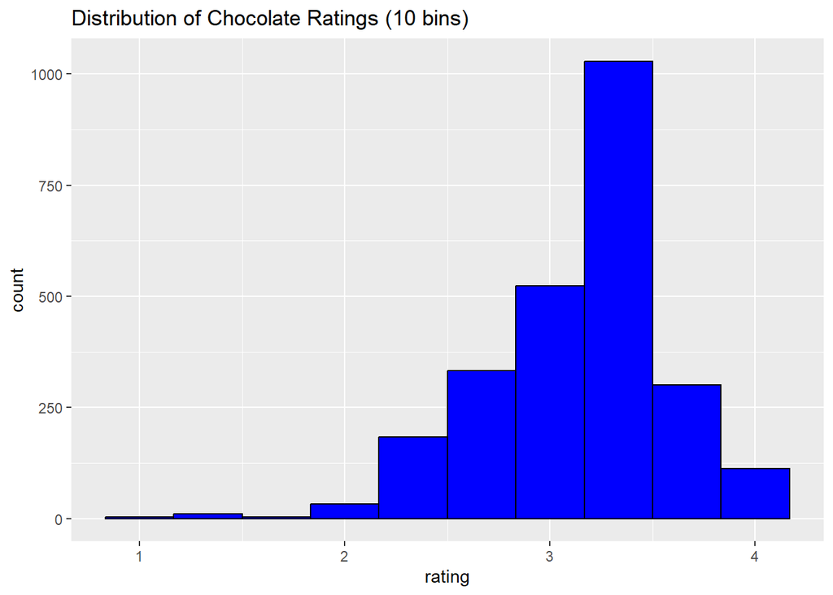

```r
# 1.build histogram
# Load ggplot2 for visualization
library(ggplot2)

# Example histogram with 10 bins(choose this one)
ggplot(chocolate, aes(x=rating)) +
  geom_histogram(bins=10, fill="blue", color="black") +
  ggtitle("Distribution of Chocolate Ratings (10 bins)")
```

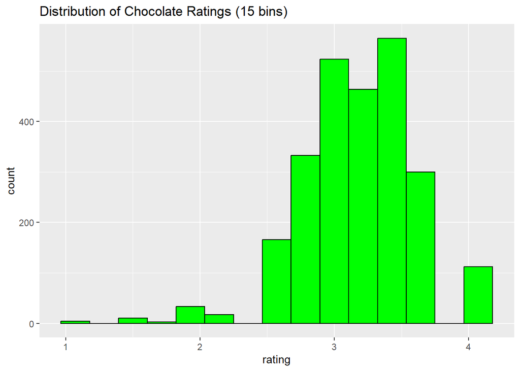

```r
# Example histogram with 15 bins
ggplot(chocolate, aes(x=rating)) +
  geom_histogram(bins=15, fill="green", color="black") +
  ggtitle("Distribution of Chocolate Ratings (15 bins)")
```

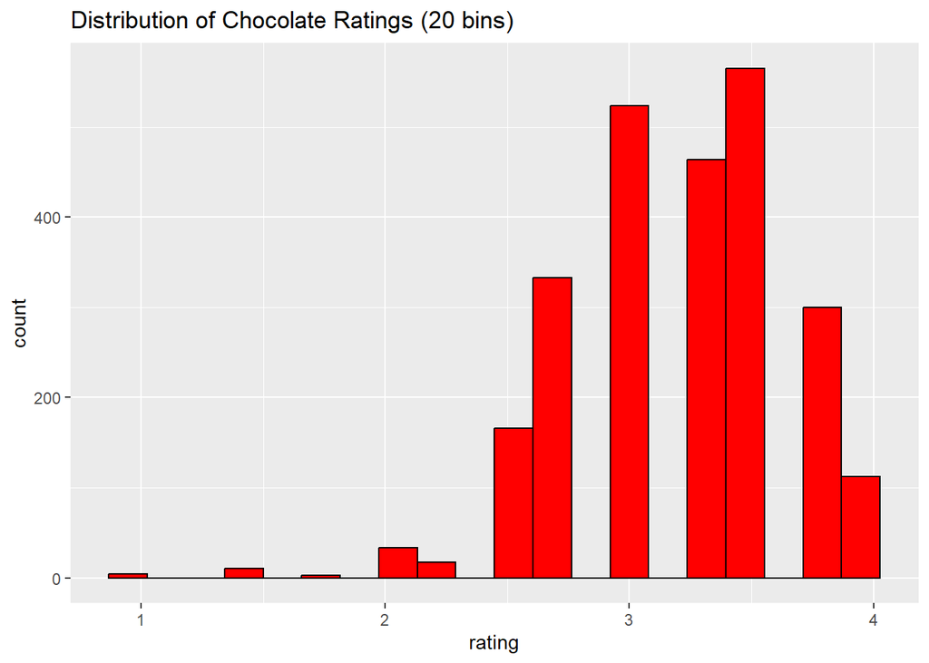

```r
# Example histogram with 20 bins
ggplot(chocolate, aes(x=rating)) +
  geom_histogram(bins=20, fill="red", color="black") +
  ggtitle("Distribution of Chocolate Ratings (20 bins)")
```

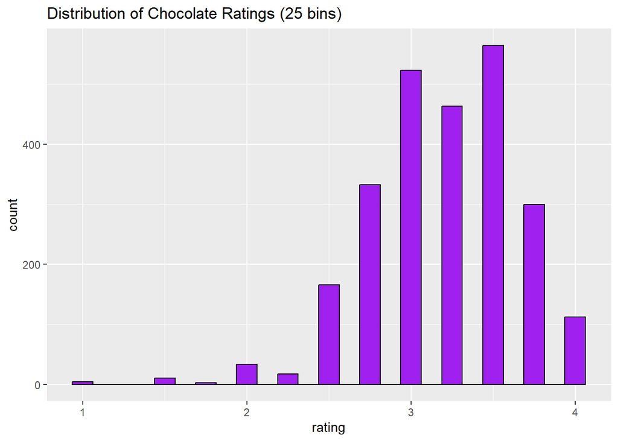

```r
# Example histogram with 25 bins
ggplot(chocolate, aes(x=rating)) +
  geom_histogram(bins=25, fill="purple", color="black") +
  ggtitle("Distribution of Chocolate Ratings (25 bins)")
```

**After looking at these histograms, we can see that 10 bins are the most appropriate. When we increase the number of bins too much, a lot of gaps appear, making the other options less suitable compared to 10 bins.**